# Домашнее задание №2, Вариант 11

Александр Кудряшов

# Задание №1

## Условие

Пусть акция стоит 600$. На рынке можно купить **Европейский Call** со **Strike price X** = 580$ по цене 30$ с погашением через **T** = 1 год. У Васи и Пети есть вера и 600$ у каждого, они хотят вложиться в эти акции. Посчитайте результаты их инвестиций (абсолютные и в процентах), если:

- Вася купит только один опцион, Петя купит одну акцию
- Вася купит опционы на все деньги, Петя купит одну акцию

а цена акции будет:

А) 560$ B) 590$ C) 600$ D) 630$ E) 670$

## Решение

Сперва разберемся в определениях. **Европейский Call** – биржевая ценная бумага, которая позволяет, но не обязывает выкупить товар по цене **Strike price** в момент времени погашения **T**. Стоит такая возможность в нашем случае 30$.

Пусть цена актива через год – **Y**. Тогда Call опцион имеет смысл использовать, если **Y** > **X**, потому что тогда купив за **X** и продав за **Y** получим мгновенный доход **Y** - **X** и прибыль **Y** - **X** - 30$, ну, если у нас, конечно, есть свободные **X** денег. Считаем, однако, что занять для того, чтобы вернуть мгновенно после занятия можно всегда. Если же цена базового актива на момент исполнения контракта **Y** <= **X**, реализовывать контракт не имеет смысла, и в таком случае мы остаемся в итоге с -30$.

Если же мы просто покупаем акцию, то через год имеем **Y** - 600$ прибыли. Cведем результаты для стратегии 1 в таблицу.

```r
r <- data.frame(Price = c(560, 590, 600, 630, 670))
r$VasyaAbsolute <- sapply(r$Price, function(Y) ifelse(Y > 580, Y - 580 - 30, -30))
r$VasyaPercentage <- round(r$VasyaAbsolute/6, digits = 2)
r$PetyaAbsolute <- r$Price - 600
r$PetyaPercentage <- round(r$PetyaAbsolute/6, d = 2)
names(r) <- c("Цена через год", "Результат Васи, $", "Результат Васи, %", "Результат Пети, $", "Результат Пети, %")
knitr::kable(r)
```

| Цена через год | Результат Васи, $ | Результат Васи, % | Результат Пети, $ | Результат Пети, % |
| --- | --- | --- | --- | --- |
| 560 | -30 | -5.00 | -40 | -6.67 |
| 590 | -20 | -3.33 | -10 | -1.67 |
| 600 | -10 | -1.67 | 0 | 0.00 |
| 630 | 20 | 3.33 | 30 | 5.00 |
| 670 | 60 | 10.00 | 70 | 11.67 |

Так вот выглядит таблица результатов инвестиций для стратегии 1: **Вася купит только один опцион, Петя купит одну акцию**. Если предположить, что свободные деньги можно вложить под какой-то безрисковый процент, Вася окажется в еще чуть более выигрышном положении, т.к. после покупки опциона у него останется сравнительно сильно больше денег, чем у Пети после покупки акции, и эти деньги можно будет вложить на год под какой-нибудь там процент. Но это уже условие исходной задачи, да и безрисковая процентная ставка неизвестна, поэтому не будем усложнять себе жизнь дополнительными расчетами.

Посчитаем теперь результаты для второй стратегии.

```r
r <- data.frame(Price = c(560, 590, 600, 630, 670))
r$VasyaAbsolute <- sapply(r$Price, function(Y) ifelse(Y > 580, (Y - 580 - 30) * 20, -30 * 20))
r$VasyaPercentage <- round(r$VasyaAbsolute/6, digits = 2)
r$PetyaAbsolute <- r$Price - 600
r$PetyaPercentage <- round(r$PetyaAbsolute/6, d = 2)
names(r) <- c("Цена через год", "Результат Васи, $", "Результат Васи, %", "Результат Пети, $", "Результат Пети, %")
knitr::kable(r)
```

| Цена через год | Результат Васи, $ | Результат Васи, % | Результат Пети, $ | Результат Пети, % |
| --- | --- | --- | --- | --- |
| 560 | -600 | -100.00 | -40 | -6.67 |
| 590 | -400 | -66.67 | -10 | -1.67 |
| 600 | -200 | -33.33 | 0 | 0.00 |
| 630 | 400 | 66.67 | 30 | 5.00 |
| 670 | 1200 | 200.00 | 70 | 11.67 |

Как видно, риски Васи сильно повысились, и он может как полностью разориться, так и заработать 200% годовых. Можно сказать, что использование опционов повышает волатильность доходов-расходов. Это при условии, что наличие опционов на рынке никак не влияет на ценообразование акций, но это, *наверное*, не так.

# Задание №2

## Условие

Пусть цена **европейского Put** с **X** = 500$ равна 6$, а текущая стоимость акции **S** = 506$. Найдите цену **европейского call** с тем же страйком **X**, если **r** = 1% и **T** - **t** = 5. Ответ округлите до целых.

## Решение

Воспользуемся put-call parity, которое заключается в следующем:
$$C - P = V_{fc} = exp(-rT)(F-X)$$
Здесь **С** – цена опцина Call, **P** – цена опциона Put, **$V_{fc}$** – справедливая цена форвардного контракта на один и тот же базовый актив с одной и той же ценой страйк **X** и датой исполнения **T**, **r** – ставка дисконтирования, **F** – форвардная цена акции на дату **T**.

Откуда оно берется? Предполагаем, что рынок, на котором мы играем, эффективен и не допускает арбитража.

Математически это означает, что любой портфель ценных бумаг этого рынка стоимостью на данный момент времени $M(t) <= 0$ для $T >= t$ так и будет оставаться $M(T) <= 0$. Или, что то же самое, не существует таких портфелей, которые бы стоили <=0 сейчас и >0 в будущем, т.е. нет возможности заработать без вложений.

Следствия из этого принципа:

1. **Теорема о монотонности**. Если портфель A стоит не меньше, чем портфель B во всех возможных состояниях рынка в дату T в будущем, то портфель A стоит не меньше, чем портфель B, во всех возможных состояниях рынка в любую более близкую дату t<T. Если кроме этого портфель А стоит больше портфеля B в каких-то состояниях рынка в дату T, то он стоит больше B в любую более близкую дату t<T.
2. **Цены европейских опционов > 0 до даты исполнения**. Если это не так, то портфель из одного этого опциона = 0 в какой-то момент до даты исполнения и > 0 в дату исполнения при некоторых состояниях рынка, что невозможно согласно принципу отсутствия арбитража.
3. Если сегодня P = Q, а в будущем P > Q при некоторых состояниях рынка, то при других состояниях рынка в том же будущем P < Q.
4. Цена call-опциона < цены базового актива. Рассмотрим два портфеля: один из call-опциона (обозначим А), другой из базового актива (обозначим B). Тогда в момент исполнения А <= B при всех состояниях рынка и A < B при некоторых состояниях рынка. Действительно, если цена на момент исполнения **S** >= страйка **X**, то портфель А приносит прибыль **S** - **X** < **S** – цены портфеля B. Если же на момент исполнения **S** < **X**, то портфель A = 0 <= B. Отсюда по теореме о монотонности A < B всегда.
5. Если ликвидная бездивидендная акция торгуется сегодня за **$S_0$** и действующая ставка процента **r**, то форвардный контракт на покупку за цену страйк **X** в дату исполнения **T** стоит
   $$V_{fc} = e^{-rT}(S_0e^{rT} - X)$$
   , где $S_0e^{rT}$ – форвардная цена акции на дату **T**.

Из всего вышесказанного:
$$C = e^{-rT}(S_0e^{rT} - X) + P = 36$$

# Задание №3

## Условие (первая часть)

Для европейских put и call построить графики цены и payoff, straddle, Put-Call Parity.

## Решение

Здесь и далее везде предполагаем, что страйк цена **X** = 50, цена пут опциона **P** = 5, цена колл опциона **С** = 10, цена акции **$S_{0}$** на момент заключения контракта = 40, период **T** = 1. Отсюда согласно put-call parity находим
$$C - P = e^{-r}(S_{0}e^r - X)$$
$$5 = e^{-r}(40e^r - 50)$$
$$35 = 50e^{-r}, \ -r = \ln 35/50, \ r = 0.36$$
Поскольку значения **X**, **P** и прочего взяты наобум, процентная ставка получилась нереалистичная: 36%. Принципиально от этого ничего не меняется, считаем, что мы, допустим, в Вэнесуэле.

```r
library(ggplot2)
library(reshape2)

price <- (1:1500)/10 # возможные цены базового актива
X <- 50 # страйк для опционов
P <- 5 # цена пут опциона
C <- 10 # цена колл опциона
r <- 0.36 # процентная ставка

# подсчитываем выплаты
put_payoff <- X - price
call_payoff <- price - X
put_payoff[which(put_payoff < 0)] <- 0
call_payoff[which(call_payoff < 0)] <- - 0
df <- data.frame(price, put_payoff, call_payoff)
df$straddle_payoff <- df$put_payoff + df$call_payoff
```

Поскольку опционы европейские, решения для цен аналитически находятся из формулы Блэка-Шоулза:
$$C(S, t) = N(d_1)S - N(d_2)Xe^{-r(T - t)}$$
$$P(S, t) = N(-d_2)Xe^{-r(T - t)} - N(-d_1)S$$
Здесь
$$d_1 = \frac{1}{\sigma \sqrt(T - t)} [ln(\frac{S}{X}) + (r + \frac{\sigma^2}{2})(T - t)]$$
,
$$d_2 = d_1 - \sigma\sqrt{T - t}$$

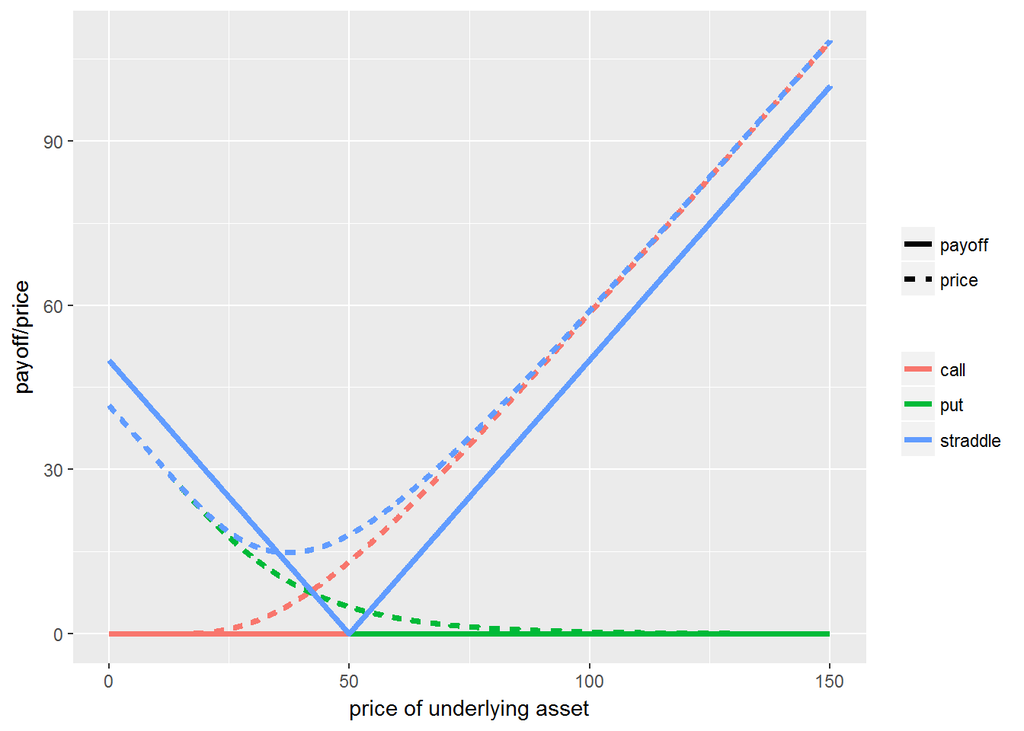

```r
T <- 1 # время экспирации
time <- 0.5 # время, для которого высчитываем цену
sigma <- 0.7
d1 <- (log(price / X) + (r + (sigma^2 / 2) * (T - time))) * 1 / sigma / (T - time)^0.5
d2 <- d1 - sigma * (T - time)^0.5

# цена опциона колл
df$call_price <- pnorm(d1) * price - pnorm(d2) * X * exp(-r * (T - time))
# цена опциона пут
df$put_price <- pnorm(-d2) * X * exp(-r * (T - time)) - pnorm(-d1) * price
# цена их вместе, т.е. цена стреддла
df$straddle_price <- df$call_price + df$put_price


melted <- melt(df, id='price')

# рисуем графики
ggplot(melted) +
  geom_line(aes(x = price,
                y = value,
                colour = sapply(strsplit(as.character(melted$variable),split="_") , "[[", 1),
                linetype = sapply(strsplit(as.character(melted$variable),split="_") , "[[", 2)), size = 1.3) +
  labs(colour = NULL, linetype = NULL) +
  ylab('payoff/price') +
  xlab('price of underlying asset')
```

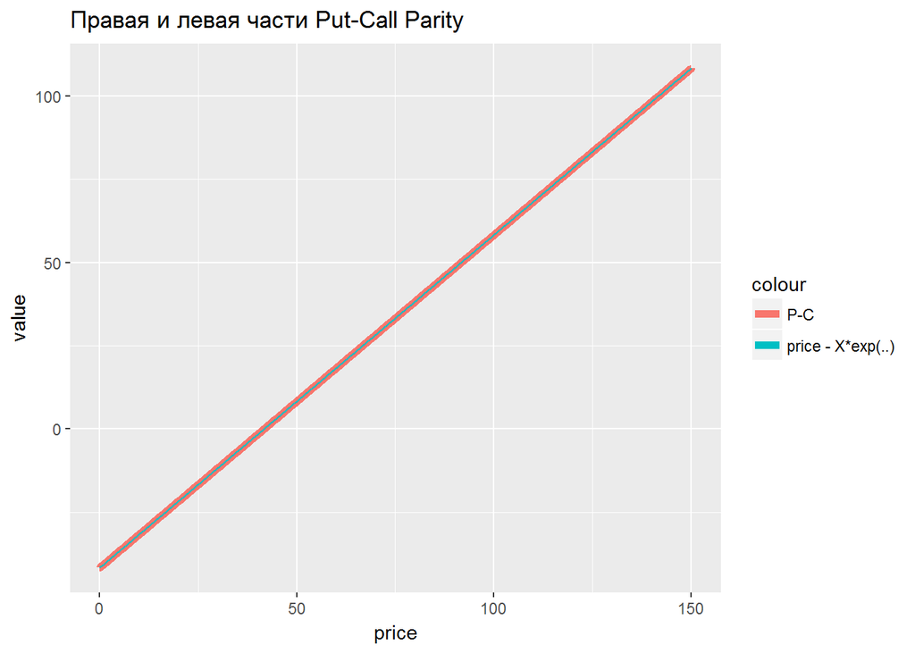

```r
left_side = df$call_price - df$put_price
right_side = price - X*exp(-r*(T-time))
ggplot(data.frame(price, left_side, right_side)) +
  geom_line(aes(x = price, y = left_side, color = 'P-C'), size = 2) +
  geom_line(aes(x = price, y = right_side, color = 'price - X*exp(..)')) +
  ggtitle("Правая и левая части Put-Call Parity") +
  ylab('value')
```

## Условие (вторая часть)

Построить графики $\Delta$, $\Gamma$, $\Omega$, Vega.

- $\Delta$ – первая производная цены опциона по цене базового актива
- $\Gamma$ – вторая производная цены опциона по цене базового актива
- $\Omega$ – -(производная цены опциона по времени)
- Vega – производная цены опциона по волатильности

## Решение

Формулы для греков возьмем отсюда.

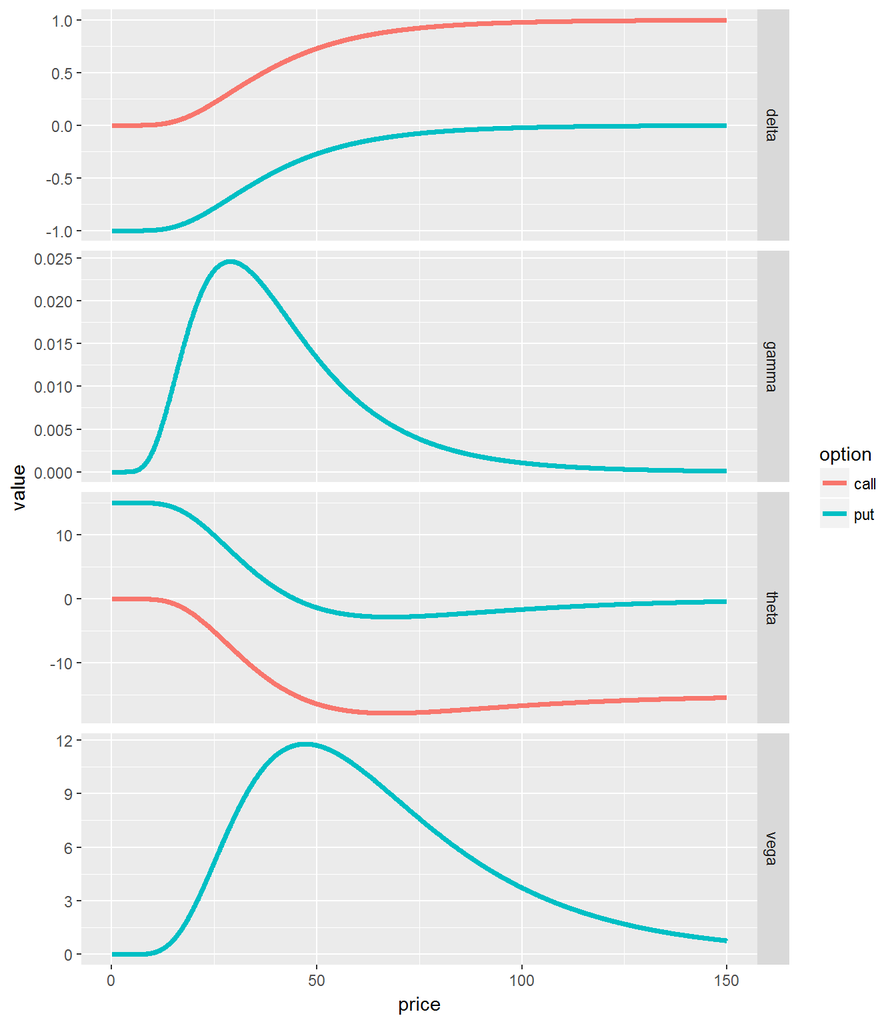

```r
delta_call <- function(S, X_=X, r_=r, dt=T-time, sigma_=sigma){
  d1 <- (log(S/X_) + (r_ + sigma_^2 / 2)*dt)/sigma_/sqrt(dt)
  pnorm(d1)
}

delta_put <- function(S, X_=X, r_=r, dt=T-time, sigma_=sigma){
  d1 <- (log(S/X_) + (r_ + sigma_^2 / 2)*dt)/sigma_/sqrt(dt)
  -pnorm(-d1)
}

gamma_call <- function(S, X_=X, r_=r, dt=T-time, sigma_=sigma){
  d2 <- (log(S/X_) + (r_ - sigma_^2 / 2)*dt)/sigma_/sqrt(dt)
  X_ * exp(-r_ * dt) * dnorm(d2)/(S^2 * sigma_ * sqrt(dt))
}

gamma_put <- gamma_call

theta_call <- function(S, X_=X, r_=r, dt=T-time, sigma_=sigma){
  d1 <- (log(S/X_) + (r_ + sigma_^2 / 2)*dt)/sigma_/sqrt(dt)
  d2 <- (log(S/X_) + (r_ - sigma_^2 / 2)*dt)/sigma_/sqrt(dt)
  -S * dnorm(d1) * sigma_ / 2 / sqrt(dt) - r_ * X_ * exp(-r_ * dt) * pnorm(d2)
}

theta_put <- function(S, X_=X, r_=r, dt=T-time, sigma_=sigma){
  d1 <- (log(S/X_) + (r_ + sigma_^2 / 2)*dt)/sigma_/sqrt(dt)
  d2 <- (log(S/X_) + (r_ - sigma_^2 / 2)*dt)/sigma_/sqrt(dt)
  -S * dnorm(d1)*sigma_/(2*sqrt(dt)) + r_*X*exp(-r_*dt)*pnorm(-d2)
 }


vega_put <- function(S, X_=X, r_=r, dt=T-time, sigma_=sigma){
  d2 <- (log(S/X_) + (r_ - sigma_^2 / 2)*dt)/sigma_/sqrt(dt)
  X_ * exp(-r_ * dt) * sqrt(dt) * dnorm(d2)
}

vega_call <- vega_put

deltadf <- data.frame(price,
                      delta_call_ <- sapply(price, delta_call),
                      delta_put_ <- sapply(price, delta_put),
                      gamma_call_ <- sapply(price, gamma_call),
                      gamma_put_ <- sapply(price, gamma_put),
                      theta_call_ <- sapply(price, theta_call),
                      theta_put_ <- sapply(price, theta_put),
                      vega_put_ <- sapply(price, vega_put),
                      vega_call_ <- sapply(price, vega_call)
                      )
melteddelta <- melt(deltadf, id='price')
melteddelta$greek = sapply(strsplit(as.character(melteddelta$variable), '[/._]'), '[[', 1)
melteddelta$option = sapply(strsplit(as.character(melteddelta$variable), '[/._]'), '[[', 2)


ggplot(melteddelta) +
  facet_grid(greek ~ ., scale = 'free') +
  geom_line(aes(x = price, y = value, colour = option), size = 1.3)
```

Поскольку $\Gamma$ и $Vega$ для put и call опционов не различаются, на соответствующих графиках put наложился на call и скрыл его.

## Условие (третья часть)

Пронаблюдать зависимость цены Европейского опциона от $T - \tau$ и от $\sigma$, сравнить с Греками.

## Решение

Для простоты рассмотрим только put опцион.

```r
X <- 50 # страйк для опционов
r <- 0.1 # процентная ставка
sigma <- 0.7 # волатильность

put_price <- function(S, X_ = X, r_ = r, dt=T-time, sigma_=sigma){
  d1 <- (log(S / X_) + (r_ + (sigma_^2 / 2) * dt)) * 1 / sigma_ / dt^0.5
  d2 <- d1 - sigma_ * dt^0.5
  pnorm(-d2) * X_ * exp(-r_ * dt) - pnorm(-d1) * S
}
```

Теперь возьмем разные значения $T - \tau$ и посмотрим на цены опциона и сопутствующую греческую производную $\Theta$.

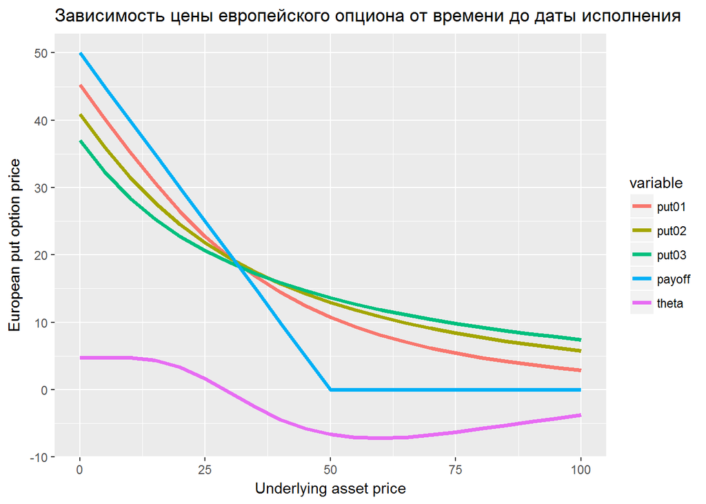

```r
library(ggplot2)

TTM <- c(1, 2, 3)
dtdf <- data.frame(price = seq(0, 100, 5))
dtdf$put01 <- sapply(dtdf$price, function(s) put_price(S=s,dt = TTM[1]))
dtdf$put02 <- sapply(dtdf$price, function(s) put_price(S=s,dt = TTM[2]))
dtdf$put03 <- sapply(dtdf$price, function(s) put_price(S=s,dt = TTM[3]))
dtdf$payoff <- sapply(X - dtdf$price, function(v) max(v, 0))
dtdf$theta <- sapply(dtdf$price, function(s) theta_put(s))
melteddtdf <- reshape2::melt(dtdf, id='price')
ggplot(melteddtdf) +
  geom_line(aes(x = price, y = value, colour = variable), size=1.3) +
  ylab('European put option price') +
  xlab('Underlying asset price') +
  ggtitle("Зависимость цены европейского опциона от времени до даты исполнения")
```

Получается, что с уменьшением времени до даты исполнения опциона его цена меняется с разной скоростью в зависимости от относительного расположения X и S. В общем, это логично, т.к. если опцион, например, out-of-the-money(выплаты по нему скорее всего не будет, и чем больше расстояние между S и X, тем больше вероятность того, что выплаты не будет) – он стоит почти ничего, и $\Theta$ почти не меняется, близка к нулю и отрицательна. Еще видно, что $\Theta$ меняет знак в той же точке, в которой цены опционов пересекают payoff. В общем, это тоже логично: с течением времени цена опциона приближается к функции выплаты, поэтому $\Theta$ должна быть направлена так, чтоб расхождение между ценой и выплатой компенсировать.

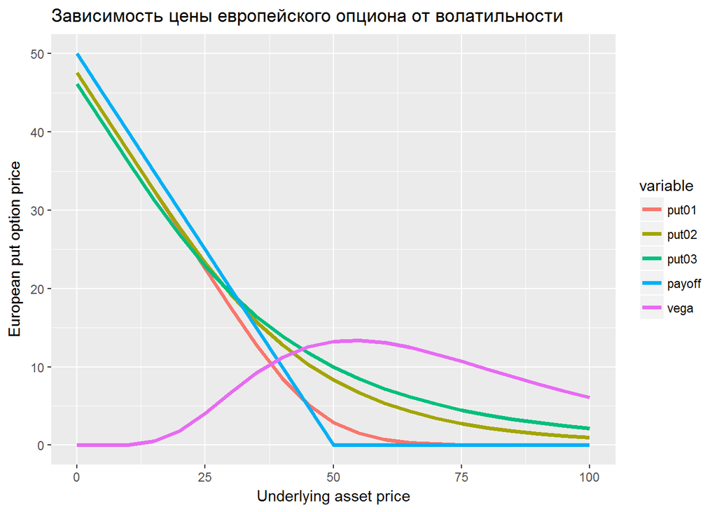

```r
sigmas <- c(0.3, 0.5, 0.8)
dtdf <- data.frame(price = seq(0, 100, 5))
dtdf$put01 <- sapply(dtdf$price, function(s) put_price(S=s,sigma_ = sigmas[1]))
dtdf$put02 <- sapply(dtdf$price, function(s) put_price(S=s,dt = sigmas[2]))
dtdf$put03 <- sapply(dtdf$price, function(s) put_price(S=s,dt = sigmas[3]))
dtdf$payoff <- sapply(X - dtdf$price, function(v) max(v, 0))
dtdf$vega <- sapply(dtdf$price, function(s) vega_put(s))
melteddtdf <- reshape2::melt(dtdf, id='price')
ggplot(melteddtdf) +
  geom_line(aes(x = price, y = value, colour = variable), size=1.3) +
  ylab('European put option price') +
  xlab('Underlying asset price') +
  ggtitle("Зависимость цены европейского опциона от волатильности")
```

Вега неотрицательна для всех цен, но больше там, где потенциальная прибыль от больше, т.е. в момент at-the-money, т.к. тут любое малое изменение волатильности может существенно повлиять на вероятность выплаты и на цену.

## Задание (четвертая часть)

Связать график $\rho$ с графиками цены Европейских опционов при различных r.

## Решение

$\rho$ – грек, который не встречался ранее. Для put опциона он выглядит так:
$$\rho = -Xdte^{-rdt}N(-d_2)$$

Посмотрим цену опциона put и график $\rho$.

[figure not shown]

```r
# функция, вычисляющая этого грека
rho <- function(S, X_=X, r_=r, dt=T-time, sigma_=sigma){
  d2 <- (log(S/X_) + (r_ - sigma_^2 / 2)*dt)/sigma_/sqrt(dt)
  -X * dt * exp(-r_ * dt) * pnorm(-d2)
}

rs <- c(0.05, 0.15, 0.3)
dtdf <- data.frame(price = seq(0, 100, 5))
dtdf$put01 <- sapply(dtdf$price, function(s) put_price(S=s,r_ = rs[1]))
dtdf$put02 <- sapply(dtdf$price, function(s) put_price(S=s,r_ = rs[2]))
dtdf$put03 <- sapply(dtdf$price, function(s) put_price(S=s,r_ = rs[3]))
dtdf$payoff <- sapply(X - dtdf$price, function(v) max(v, 0))
dtdf$rho <- sapply(dtdf$price, function(s) rho(s))
melteddtdf <- reshape2::melt(dtdf, id='price')
ggplot(melteddtdf) +
  geom_line(aes(x = price, y = value, colour = variable), size=1.3) +
  ylab('European put option price') +
  xlab('Underlying asset price') +
  ggtitle("Зависимость цены европейского опциона от волатильности")
```

Тоже все логично. $\rho$ всюду отрицательна, т.к. везде при любых обстоятельствах при меньшей ставке дисконтирования деньги обесцениваются медленнее.Поэтому при росте $\rho$ цена опциона в текущих деньгах уменьшается.